# B80_Inversion_About_the_Mean

| Abuzer Yakaryilmaz \| May 1, 2019 (updated) |
| --- |
| This cell contains some macros. If there is a problem with displaying mathematical formulas, please run this cell to load these macros. |

$ \newcommand{\bra}[1]{\langle #1|} $ $ \newcommand{\ket}[1]{|#1\rangle} $ $ \newcommand{\braket}[2]{\langle #1|#2\rangle} $ $ \newcommand{\dot}[2]{ #1 \cdot #2} $ $ \newcommand{\biginner}[2]{\left\langle #1,#2\right\rangle} $ $ \newcommand{\mymatrix}[2]{\left( \begin{array}{#1} #2\end{array} \right)} $ $ \newcommand{\myvector}[1]{\mymatrix{c}{#1}} $ $ \newcommand{\myrvector}[1]{\mymatrix{r}{#1}} $ $ \newcommand{\mypar}[1]{\left( #1 \right)} $ $ \newcommand{\mybigpar}[1]{ \Big( #1 \Big)} $ $ \newcommand{\sqrttwo}{\frac{1}{\sqrt{2}}} $ $ \newcommand{\dsqrttwo}{\dfrac{1}{\sqrt{2}}} $ $ \newcommand{\onehalf}{\frac{1}{2}} $ $ \newcommand{\donehalf}{\dfrac{1}{2}} $ $ \newcommand{\hadamard}{ \mymatrix{rr}{ \sqrttwo & \sqrttwo \\ \sqrttwo & -\sqrttwo }} $ $ \newcommand{\vzero}{\myvector{1\\0}} $ $ \newcommand{\vone}{\myvector{0\\1}} $ $ \newcommand{\vhadamardzero}{\myvector{ \sqrttwo \\ \sqrttwo } } $ $ \newcommand{\vhadamardone}{ \myrvector{ \sqrttwo \\ -\sqrttwo } } $ $ \newcommand{\myarray}[2]{ \begin{array}{#1}#2\end{array}} $ $ \newcommand{\X}{ \mymatrix{cc}{0 & 1 \\ 1 & 0} } $ $ \newcommand{\Z}{ \mymatrix{rr}{1 & 0 \\ 0 & -1} } $ $ \newcommand{\Htwo}{ \mymatrix{rrrr}{ \frac{1}{2} & \frac{1}{2} & \frac{1}{2} & \frac{1}{2} \\ \frac{1}{2} & -\frac{1}{2} & \frac{1}{2} & -\frac{1}{2} \\ \frac{1}{2} & \frac{1}{2} & -\frac{1}{2} & -\frac{1}{2} \\ \frac{1}{2} & -\frac{1}{2} & -\frac{1}{2} & \frac{1}{2} } } $ $ \newcommand{\CNOT}{ \mymatrix{cccc}{1 & 0 & 0 & 0 \\ 0 & 1 & 0 & 0 \\ 0 & 0 & 0 & 1 \\ 0 & 0 & 1 & 0} } $ $ \newcommand{\norm}[1]{ \left\lVert #1 \right\rVert } $

## Inversion About the Mean

We play a simple game to give some ideas about how Grover's search algorithm works.

We have a list of N elements.

Some of them are marked ones.

At the beginning each has a value of 1.

Each iteration of the game has two phases:

1. **Query**: In this phase, each marked element is detected, and then its sign is flipped.
2. **Inversion**: In this phase, the value of each element is reflected over the mean of all values.

### Task 1

We play this game for $ N = 8 $.

Suppose that only the 4th element is marked.

We can visualize the values of elements in the list in the beginning as follows.

```
<BarContainer object of 8 artists>
```

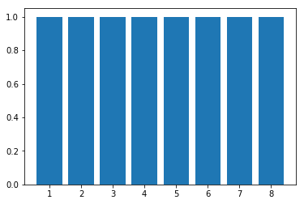

```python
from matplotlib.pyplot import bar

labels = []
L = []
for i in range(8):
    labels = labels + [i+1]
    L  = L + [1]

# visualize the values of elements in the list
bar(labels,L)
```

Iterate the game for one step and visualize the values of elements in the list after each phase.

1st step - query phase:

```
<BarContainer object of 8 artists>
```

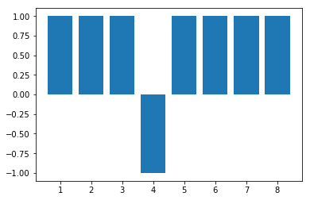

```python
#
# 1st step - query
#
# 4th element is marked flip the sign
L[3] = -1 * L[3]

# visualize the values of elements in the list
bar(labels,L)
```

1st step - inversion phase:

```
<BarContainer object of 8 artists>
```

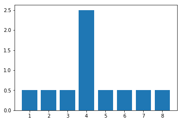

```python
#
# 1st step - inversion
#
import numpy as np
# find reflection over the mean

sum = 0
for i in range(len(L)):
    sum += L[i]

# mean of all values
mean = sum / len(L)

# reflection over the mean
for i in range(len(L)):
    value = L[i]
    new_value = mean - (L[i]-mean)
    L[i] = new_value

# visualize the values of elements in the list
bar(labels,L)
```

Iterate the game for one more step and visualize the values of elements in the list after each phase.

2nd step - query phase:

```
<BarContainer object of 8 artists>
```

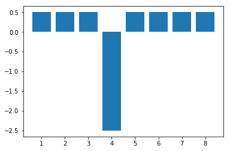

```python
#
# 2nd step - query
#
L[3] = -1 * L[3]

# visualize the values of elements in the list
bar(labels,L)
```

2nd step - inversion phase:

```
<BarContainer object of 8 artists>
```

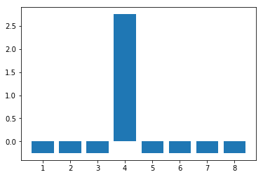

```python
#
# 2nd step - inversion
#

sum = 0
for i in range(len(L)):
    sum += L[i]

# mean of all values
mean = sum / len(L)

# reflection over the mean
for i in range(len(L)):
    value = L[i]
    new_value = mean - (L[i]-mean)
    L[i] = new_value

# visualize the values of elements in the list
bar(labels,L)
```

Iterate the game three more steps and visualize the values of elements in the list at the end.

```
<BarContainer object of 8 artists>
```

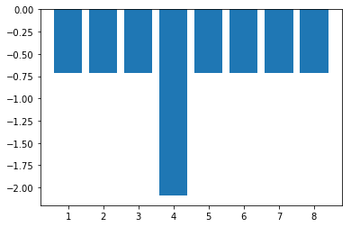

```python
#
# your code is here
#
# Construct the list with all elements 1


def query(L):
    L[3] = -1 * L[3]
    return L
def inversion(L):
    sum = 0
    for i in range(len(L)):
        sum += L[i]

    # mean of all values
    mean = sum / len(L)

    # reflection over the mean
    for i in range(len(L)):
        value = L[i]
        new_value = mean - (L[i]-mean)
        L[i] = new_value
    return L

# iterate same steps 3 times
for i in range(3):
    L = query(L)
    L = inversion(L)

# visualize the values of elements in the list
bar(labels,L)
```

click for our solution

### Task 2

We play this game for $ N = 16 $.

Suppose that only the 11th element is marked.

```
Value of 11th element after  1  iteration:  2.75

Value of 11th element after  2  iteration:  3.8125

Value of 11th element after  3  iteration:  3.921875

Value of 11th element after  4  iteration:  3.05078125

Value of 11th element after  5  iteration:  1.4169921875

Value of 11th element after  6  iteration:  -0.571044921875

Value of 11th element after  7  iteration:  -2.41632080078125

Value of 11th element after  8  iteration:  -3.6575164794921875

Value of 11th element after  9  iteration:  -3.984333038330078

Value of 11th element after  10  iteration:  -3.315066337585449

Value of 11th element after  11  iteration:  -1.817033052444458

Value of 11th element after  12  iteration:  0.1352584958076477

Value of 11th element after  13  iteration:  2.0537354201078415

Value of 11th element after  14  iteration:  3.458778489381075

Value of 11th element after  15  iteration:  3.9991269363090396

Value of 11th element after  16  iteration:  3.5396936491597444
```

```
<BarContainer object of 16 artists>
```

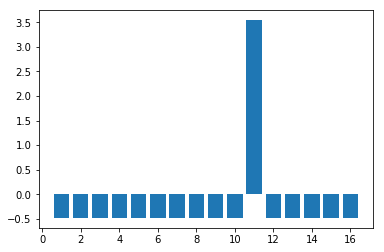

```python
#
# your code is here
#
labels = []
L = []
for i in range(16):
    labels = labels + [i+1]
    L  = L + [1]

def query(L):
    L[10] = -1 * L[10]
    return L
def inversion(L):
    sum = 0
    for i in range(len(L)):
        sum += L[i]

    # mean of all values
    mean = sum / len(L)

    # reflection over the mean
    for i in range(len(L)):
        value = L[i]
        new_value = mean - (L[i]-mean)
        L[i] = new_value
    return L

# iterate the game 16 times
for i in range(1, 17):
    L = query(L)
    L = inversion(L)
    print("Value of 11th element after ", i, " iteration: ", L[10] )
    print()
# visualize the values of elements in the list
bar(labels,L)
```

click for our solution

**Observations:**

The absolute value of the marked element is increasing and decreasing during the iterations.

Its behavior is similar to rotations.

### Modified Game

We modify the game by guaranteeing that the list represents a quantum state.

### Task 3

What are the initial values for the modifed game if $ N=8 $?

#### Answer for Task 3

The list is $ [ a,a,a,a,a,a,a,a ] $ at the beginning.

If it is a quantum state, then $ 8a^2 = 1 $ and $ a = \frac{1}{2\sqrt{2}} $.

click for our solution

### Task 4

Iterate the modified game for $ N = 8 $ where the second element is the only marked element.

Print the list after each phase.

Check whether the length of list is 1 after each iteration.

```
0.354  0.354  0.354  0.354  0.354  0.354  0.354  0.354
1 th iteration:
0.354  -0.354  0.354  0.354  0.354  0.354  0.354  0.354
mean =  0.265
length of list is 1.0
0.177  0.884  0.177  0.177  0.177  0.177  0.177  0.177

2 th iteration:
0.177  -0.884  0.177  0.177  0.177  0.177  0.177  0.177
mean =  0.044
length of list is 1.0
-0.088  0.972  -0.088  -0.088  -0.088  -0.088  -0.088  -0.088

3 th iteration:
-0.088  -0.972  -0.088  -0.088  -0.088  -0.088  -0.088  -0.088
mean =  -0.199
length of list is 1.0
-0.309  0.575  -0.309  -0.309  -0.309  -0.309  -0.309  -0.309

4 th iteration:
-0.309  -0.575  -0.309  -0.309  -0.309  -0.309  -0.309  -0.309
mean =  -0.343
length of list is 1.0
-0.376  -0.11  -0.376  -0.376  -0.376  -0.376  -0.376  -0.376

5 th iteration:
-0.376  0.11  -0.376  -0.376  -0.376  -0.376  -0.376  -0.376
mean =  -0.315
length of list is 1.0
-0.254  -0.74  -0.254  -0.254  -0.254  -0.254  -0.254  -0.254

6 th iteration:
-0.254  0.74  -0.254  -0.254  -0.254  -0.254  -0.254  -0.254
mean =  -0.13
length of list is 1.0
-0.006  -1.0  -0.006  -0.006  -0.006  -0.006  -0.006  -0.006

7 th iteration:
-0.006  1.0  -0.006  -0.006  -0.006  -0.006  -0.006  -0.006
mean =  0.12
length of list is 1.0
0.246  -0.76  0.246  0.246  0.246  0.246  0.246  0.246

8 th iteration:
0.246  0.76  0.246  0.246  0.246  0.246  0.246  0.246
mean =  0.31
length of list is 1.0
0.374  -0.139  0.374  0.374  0.374  0.374  0.374  0.374

9 th iteration:
0.374  0.139  0.374  0.374  0.374  0.374  0.374  0.374
mean =  0.345
length of list is 1.0
0.316  0.55  0.316  0.316  0.316  0.316  0.316  0.316

10 th iteration:
0.316  -0.55  0.316  0.316  0.316  0.316  0.316  0.316
mean =  0.207
length of list is 1.0
0.099  0.965  0.099  0.099  0.099  0.099  0.099  0.099
```

```
<BarContainer object of 8 artists>
```

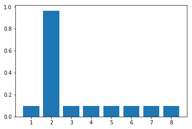

```python
#
# your code is here
#
N = 8
marked = 1

L = []

for i in range(N):
    L = L + [1/(N**0.5)]

# print the elements of a given list with a given precision
def print_list(L,precision):
    output = ""
    for i in range(len(L)):
        output = output + str(round(L[i],precision))+"  "
    print(output)

print_list(L,3)

for i in range(10):
    print((i+1),"th iteration:")
    # flip the sign of the marked element
    L[marked] = -1 * L[marked]

    # print after query phase
    print_list(L,3)

     # summation of all values
    sum = 0
    for i in range(len(L)):
        sum += L[i]

    # mean of all values
    mean = sum / len(L)
    print("mean = ",round(mean,3))

    # reflection over mean
    for i in range(len(L)):
        value = L[i]
        new_value = mean - (L[i]-mean)
        L[i] = new_value

    # calculate the length of the list
    length_of_list = 0
    for j in range(len(L)):
        length_of_list += L[j]*L[j]

    print("length of list is",round(length_of_list,3))
    # print after inversion phase
    print_list(L,3)
    print()
# visualize the values of elements in the list
bar(labels,L)
```

click for our solution

### Task 5

Repeat Task 4 for $ N = 16 $ where the marked elements are the first, third and tenth elements.

```python
#
# your code is here
#
N = 16
marked_elements = [0,2,9]

L = []

for i in range(N):
    L = L + [1/(N**0.5)]

# print the elements of a given list with a given precision
def print_list(L,precision):
    output = ""
    for i in range(len(L)):
        output = output + str(round(L[i],precision))+"  "
    print(output)

print_list(L,3)

for i in range(10):
    print((i+1),"th iteration:")
    # flip the sign of the marked element
    for marked in marked_elements:
        L[marked] = -1 * L[marked]

    # print after query phase
    print_list(L,3)

     # summation of all values
    sum = 0
    for i in range(len(L)):
        sum += L[i]

    # mean of all values
    mean = sum / len(L)

    # reflection over mean
    for i in range(len(L)):
        value = L[i]
        new_value = mean - (L[i]-mean)
        L[i] = new_value

    # calculate the length of the list
    length_of_list = 0
    for j in range(len(L)):
        length_of_list += L[j]*L[j]

    print("length of list is",round(length_of_list,3))
    # print after inversion phase
    print_list(L,3)
    print()
```

```
0.25  0.25  0.25  0.25  0.25  0.25  0.25  0.25  0.25  0.25  0.25  0.25  0.25  0.25  0.25  0.25
1 th iteration:
-0.25  0.25  -0.25  0.25  0.25  0.25  0.25  0.25  0.25  -0.25  0.25  0.25  0.25  0.25  0.25  0.25
length of list is 1.0
0.562  0.062  0.562  0.062  0.062  0.062  0.062  0.062  0.062  0.562  0.062  0.062  0.062  0.062  0.062  0.062

2 th iteration:
-0.562  0.062  -0.562  0.062  0.062  0.062  0.062  0.062  0.062  -0.562  0.062  0.062  0.062  0.062  0.062  0.062
length of list is 1.0
0.453  -0.172  0.453  -0.172  -0.172  -0.172  -0.172  -0.172  -0.172  0.453  -0.172  -0.172  -0.172  -0.172  -0.172  -0.172

3 th iteration:
-0.453  -0.172  -0.453  -0.172  -0.172  -0.172  -0.172  -0.172  -0.172  -0.453  -0.172  -0.172  -0.172  -0.172  -0.172  -0.172
length of list is 1.0
0.004  -0.277  0.004  -0.277  -0.277  -0.277  -0.277  -0.277  -0.277  0.004  -0.277  -0.277  -0.277  -0.277  -0.277  -0.277

4 th iteration:
-0.004  -0.277  -0.004  -0.277  -0.277  -0.277  -0.277  -0.277  -0.277  -0.004  -0.277  -0.277  -0.277  -0.277  -0.277  -0.277
length of list is 1.0
-0.448  -0.175  -0.448  -0.175  -0.175  -0.175  -0.175  -0.175  -0.175  -0.448  -0.175  -0.175  -0.175  -0.175  -0.175  -0.175

5 th iteration:
0.448  -0.175  0.448  -0.175  -0.175  -0.175  -0.175  -0.175  -0.175  0.448  -0.175  -0.175  -0.175  -0.175  -0.175  -0.175
length of list is 1.0
-0.564  0.059  -0.564  0.059  0.059  0.059  0.059  0.059  0.059  -0.564  0.059  0.059  0.059  0.059  0.059  0.059

6 th iteration:
0.564  0.059  0.564  0.059  0.059  0.059  0.059  0.059  0.059  0.564  0.059  0.059  0.059  0.059  0.059  0.059
length of list is 1.0
-0.257  0.248  -0.257  0.248  0.248  0.248  0.248  0.248  0.248  -0.257  0.248  0.248  0.248  0.248  0.248  0.248

7 th iteration:
0.257  0.248  0.257  0.248  0.248  0.248  0.248  0.248  0.248  0.257  0.248  0.248  0.248  0.248  0.248  0.248
length of list is 1.0
0.243  0.252  0.243  0.252  0.252  0.252  0.252  0.252  0.252  0.243  0.252  0.252  0.252  0.252  0.252  0.252

8 th iteration:
-0.243  0.252  -0.243  0.252  0.252  0.252  0.252  0.252  0.252  -0.243  0.252  0.252  0.252  0.252  0.252  0.252
length of list is 1.0
0.561  0.066  0.561  0.066  0.066  0.066  0.066  0.066  0.066  0.561  0.066  0.066  0.066  0.066  0.066  0.066

9 th iteration:
-0.561  0.066  -0.561  0.066  0.066  0.066  0.066  0.066  0.066  -0.561  0.066  0.066  0.066  0.066  0.066  0.066
length of list is 1.0
0.458  -0.169  0.458  -0.169  -0.169  -0.169  -0.169  -0.169  -0.169  0.458  -0.169  -0.169  -0.169  -0.169  -0.169  -0.169

10 th iteration:
-0.458  -0.169  -0.458  -0.169  -0.169  -0.169  -0.169  -0.169  -0.169  -0.458  -0.169  -0.169  -0.169  -0.169  -0.169  -0.169
length of list is 1.0
0.012  -0.277  0.012  -0.277  -0.277  -0.277  -0.277  -0.277  -0.277  0.012  -0.277  -0.277  -0.277  -0.277  -0.277  -0.277
```

click for our solution

### Task 6

Repeat Task 4 for $ N = 16 $ where the first 12 elements are marked.

```python
#
# your code is here
#
N = 16
marked_elements = range(12)

L = []

for i in range(N):
    L = L + [1/(N**0.5)]

# print the elements of a given list with a given precision
def print_list(L,precision):
    output = ""
    for i in range(len(L)):
        output = output + str(round(L[i],precision))+"  "
    print(output)

print_list(L,3)

for i in range(10):
    print((i+1),"th iteration:")
    # flip the sign of the marked element
    for marked in marked_elements:
        L[marked] = -1 * L[marked]

    # print after query phase
    print_list(L,3)

     # summation of all values
    sum = 0
    for i in range(len(L)):
        sum += L[i]

    # mean of all values
    mean = sum / len(L)

    # reflection over mean
    for i in range(len(L)):
        value = L[i]
        new_value = mean - (L[i]-mean)
        L[i] = new_value

    # calculate the length of the list
    length_of_list = 0
    for j in range(len(L)):
        length_of_list += L[j]*L[j]

    print("length of list is",round(length_of_list,3))
    # print after inversion phase
    print_list(L,3)
    print()
```

```
0.25  0.25  0.25  0.25  0.25  0.25  0.25  0.25  0.25  0.25  0.25  0.25  0.25  0.25  0.25  0.25
1 th iteration:
-0.25  -0.25  -0.25  -0.25  -0.25  -0.25  -0.25  -0.25  -0.25  -0.25  -0.25  -0.25  0.25  0.25  0.25  0.25
length of list is 1.0
0.0  0.0  0.0  0.0  0.0  0.0  0.0  0.0  0.0  0.0  0.0  0.0  -0.5  -0.5  -0.5  -0.5

2 th iteration:
-0.0  -0.0  -0.0  -0.0  -0.0  -0.0  -0.0  -0.0  -0.0  -0.0  -0.0  -0.0  -0.5  -0.5  -0.5  -0.5
length of list is 1.0
-0.25  -0.25  -0.25  -0.25  -0.25  -0.25  -0.25  -0.25  -0.25  -0.25  -0.25  -0.25  0.25  0.25  0.25  0.25

3 th iteration:
0.25  0.25  0.25  0.25  0.25  0.25  0.25  0.25  0.25  0.25  0.25  0.25  0.25  0.25  0.25  0.25
length of list is 1.0
0.25  0.25  0.25  0.25  0.25  0.25  0.25  0.25  0.25  0.25  0.25  0.25  0.25  0.25  0.25  0.25

4 th iteration:
-0.25  -0.25  -0.25  -0.25  -0.25  -0.25  -0.25  -0.25  -0.25  -0.25  -0.25  -0.25  0.25  0.25  0.25  0.25
length of list is 1.0
0.0  0.0  0.0  0.0  0.0  0.0  0.0  0.0  0.0  0.0  0.0  0.0  -0.5  -0.5  -0.5  -0.5

5 th iteration:
-0.0  -0.0  -0.0  -0.0  -0.0  -0.0  -0.0  -0.0  -0.0  -0.0  -0.0  -0.0  -0.5  -0.5  -0.5  -0.5
length of list is 1.0
-0.25  -0.25  -0.25  -0.25  -0.25  -0.25  -0.25  -0.25  -0.25  -0.25  -0.25  -0.25  0.25  0.25  0.25  0.25

6 th iteration:
0.25  0.25  0.25  0.25  0.25  0.25  0.25  0.25  0.25  0.25  0.25  0.25  0.25  0.25  0.25  0.25
length of list is 1.0
0.25  0.25  0.25  0.25  0.25  0.25  0.25  0.25  0.25  0.25  0.25  0.25  0.25  0.25  0.25  0.25

7 th iteration:
-0.25  -0.25  -0.25  -0.25  -0.25  -0.25  -0.25  -0.25  -0.25  -0.25  -0.25  -0.25  0.25  0.25  0.25  0.25
length of list is 1.0
0.0  0.0  0.0  0.0  0.0  0.0  0.0  0.0  0.0  0.0  0.0  0.0  -0.5  -0.5  -0.5  -0.5

8 th iteration:
-0.0  -0.0  -0.0  -0.0  -0.0  -0.0  -0.0  -0.0  -0.0  -0.0  -0.0  -0.0  -0.5  -0.5  -0.5  -0.5
length of list is 1.0
-0.25  -0.25  -0.25  -0.25  -0.25  -0.25  -0.25  -0.25  -0.25  -0.25  -0.25  -0.25  0.25  0.25  0.25  0.25

9 th iteration:
0.25  0.25  0.25  0.25  0.25  0.25  0.25  0.25  0.25  0.25  0.25  0.25  0.25  0.25  0.25  0.25
length of list is 1.0
0.25  0.25  0.25  0.25  0.25  0.25  0.25  0.25  0.25  0.25  0.25  0.25  0.25  0.25  0.25  0.25

10 th iteration:
-0.25  -0.25  -0.25  -0.25  -0.25  -0.25  -0.25  -0.25  -0.25  -0.25  -0.25  -0.25  0.25  0.25  0.25  0.25
length of list is 1.0
0.0  0.0  0.0  0.0  0.0  0.0  0.0  0.0  0.0  0.0  0.0  0.0  -0.5  -0.5  -0.5  -0.5
```

click for our solution

### Grover's quantum search algorithm

The modifed game is the main part of Grover's quantum search algorithm.

Suppose that we are given an unordered list and we make a search of a specific element called as marked.

We access the list via an oracle.

If there are $ N $ elements in the list, we can use $ \log(N) $ qubits. (Assume that $N$ is a power of 2.)

Each basis state, i.e., $ \ket{0 \cdots 0}, \ldots, \ket{1 \cdots 1} $, corresponds to an index of the list.

If the searched element is detected, then the oracle simply flips the sign of the value of the corresponding index.

At the beginning, Hadamard operator is applied to each qubit. Thus, the amplitude of each basis state is set to $ \ket{1}{\sqrt{N}} $.

We can interpret this as all indices start the game with the same amplitude.

Then, the game starts to iterate, and the amplitudes of marked and unmarked elements are changed

#### The number of iterations

When the number of marked elements are less than the unmarked elements, the amplitudes of marked elements start to increase by approaching to 1.

Then, we reach the first peak such that the probability of observing a marked element takes its maximum value for the first part.

After passing this point, the amplitudes of marked elements start to decrease by approaching to 0.

#### Phases

The operator in each phase is unitary.

The unitary matrix in the query phase depends on the input, but the unitary operator in the inversion phase does not depend on the input.

**In the query phase**, the oracle uses a well-known phonemena called phase kickback (next notebook). We omit the further details of how to construct such oracle.

**In the inversion phase**, for the value $ x $, the new value is calculated as $ mean - (x - mean) = 2mean -x $.

The mean of a column vector of size $ N $ can be calculated by multiplying it with the following row vector from the left:

$$ \myvector{ \frac{1}{N} ~~ \frac{1}{N} ~~ \cdots ~~ \frac{1}{N}} . $$

When considering all elements in the list, we work with a matrix. The matrix for the second phase should be

$$ D = 2 \mymatrix{ccc}{ \frac{1}{N} & \cdots & \frac{1}{N} \\ \vdots & \ddots & \vdots \\ \frac{1}{N} & \cdots & \frac{1}{N} \\ } - I . $$

### Task 7

Convience yourself that $ D \myvector{x_1 \\ \vdots \\ x_N} = \myvector{ 2m-x_1 \\ \vdots \\ 2m-x_N } $, where $ m = \dfrac{ \sum_{i=1}^N x_i } { N} $.

### Task 8

Let $ A = \mymatrix{ccc}{ \frac{1}{N} & \cdots & \frac{1}{N} \\ \vdots & \ddots & \vdots \\ \frac{1}{N} & \cdots & \frac{1}{N} \\ } $. Convience yourself that $ A^2 = A $ and $ D^T = D $.

Since $ D = 2A - I $, convience yourself that $ D $ is unitary by showing that $ D^T \cdot D = I $, i.e., $ (2A-I)(2A-I) = I $.